# HW1

Author

Clara Bowman

```r
library(dplyr)
library(leaflet)
library(ggplot2)
library(stringr)
library(maps)
```

## 1. EDA Steps 1-5

Read in data

```r
pm_2005 <- read.csv("pm2.5_2005.csv")
pm_2025 <- read.csv("pm2.5_2025.csv")
```

Check Dimensions

```r
print(dim(pm_2005))
```

```
[1] 5280   22
```

```r
print(dim(pm_2025))
```

```
[1] 9934   22
```

Check Summaries

```r
summary(pm_2005)
```

```
     Date              Source             Site.ID               POC
 Length:5280        Length:5280        Min.   :260050003   Min.   :1.000
 Class :character   Class :character   1st Qu.:260710001   1st Qu.:1.000
 Mode  :character   Mode  :character   Median :261210040   Median :1.000
                                       Mean   :261080759   Mean   :1.511
                                       3rd Qu.:261630001   3rd Qu.:1.000
                                       Max.   :261639901   Max.   :5.000

 Daily.Mean.PM2.5.Concentration    Units           Daily.AQI.Value
 Min.   : 0.00                  Length:5280        Min.   :  0.00
 1st Qu.: 6.20                  Class :character   1st Qu.: 34.00
 Median :11.00                  Mode  :character   Median : 55.00
 Mean   :13.77                                     Mean   : 54.14
 3rd Qu.:18.70                                     3rd Qu.: 69.00
 Max.   :81.60                                     Max.   :169.00

 Local.Site.Name    Daily.Obs.Count Percent.Complete AQS.Parameter.Code
 Length:5280        Min.   :1       Min.   :100      Min.   :88101
 Class :character   1st Qu.:1       1st Qu.:100      1st Qu.:88101
 Mode  :character   Median :1       Median :100      Median :88101
                    Mean   :1       Mean   :100      Mean   :88171
                    3rd Qu.:1       3rd Qu.:100      3rd Qu.:88101
                    Max.   :1       Max.   :100      Max.   :88502

 AQS.Parameter.Description  Method.Code  Method.Description   CBSA.Code
 Length:5280               Min.   :118   Length:5280        Min.   :11460
 Class :character          1st Qu.:118   Class :character   1st Qu.:19820
 Mode  :character          Median :118   Mode  :character   Median :19820
                           Mean   :233                      Mean   :24127
                           3rd Qu.:118                      3rd Qu.:26340
                           Max.   :810                      Max.   :42300
                                                            NA's   :142
  CBSA.Name         State.FIPS.Code    State           County.FIPS.Code
 Length:5280        Min.   :26      Length:5280        Min.   :  5
 Class :character   1st Qu.:26      Class :character   1st Qu.: 71
 Mode  :character   Median :26      Mode  :character   Median :121
                    Mean   :26                         Mean   :108
                    3rd Qu.:26                         3rd Qu.:163
                    Max.   :26                         Max.   :163

    County          Site.Latitude   Site.Longitude
 Length:5280        Min.   :41.76   Min.   :-89.15
 Class :character   1st Qu.:42.28   1st Qu.:-85.67
 Mode  :character   Median :42.73   Median :-83.89
                    Mean   :43.13   Mean   :-84.40
                    3rd Qu.:42.98   3rd Qu.:-83.20
                    Max.   :47.92   Max.   :-82.46
```

```r
summary(pm_2025)
```

```
     Date              Source             Site.ID               POC
 Length:9934        Length:9934        Min.   :260050003   Min.   :1.000
 Class :character   Class :character   1st Qu.:260839000   1st Qu.:1.000
 Mode  :character   Mode  :character   Median :261390005   Median :1.000
                                       Mean   :261212947   Mean   :1.137
                                       3rd Qu.:261630019   3rd Qu.:1.000
                                       Max.   :261630100   Max.   :3.000

 Daily.Mean.PM2.5.Concentration    Units           Daily.AQI.Value
 Min.   :  0.000                Length:9934        Min.   :  0.00
 1st Qu.:  4.000                Class :character   1st Qu.: 22.00
 Median :  6.300                Mode  :character   Median : 35.00
 Mean   :  8.305                                   Mean   : 38.72
 3rd Qu.: 10.100                                   3rd Qu.: 53.00
 Max.   :116.000                                   Max.   :193.00

 Local.Site.Name    Daily.Obs.Count Percent.Complete AQS.Parameter.Code
 Length:9934        Min.   :1       Min.   :100      Min.   :88101
 Class :character   1st Qu.:1       1st Qu.:100      1st Qu.:88101
 Mode  :character   Median :1       Median :100      Median :88101
                    Mean   :1       Mean   :100      Mean   :88103
                    3rd Qu.:1       3rd Qu.:100      3rd Qu.:88101
                    Max.   :1       Max.   :100      Max.   :88502

 AQS.Parameter.Description  Method.Code   Method.Description   CBSA.Code
 Length:9934               Min.   :145    Length:9934        Min.   :10300
 Class :character          1st Qu.:170    Class :character   1st Qu.:19820
 Mode  :character          Median :636    Mode  :character   Median :19820
                           Mean   :505                       Mean   :20534
                           3rd Qu.:636                       3rd Qu.:24340
                           Max.   :707                       Max.   :32100
                           NA's   :2543                      NA's   :712
  CBSA.Name         State.FIPS.Code    State           County.FIPS.Code
 Length:9934        Min.   :26      Length:9934        Min.   :  5.0
 Class :character   1st Qu.:26      Class :character   1st Qu.: 83.0
 Mode  :character   Median :26      Mode  :character   Median :139.0
                    Mean   :26                         Mean   :121.3
                    3rd Qu.:26                         3rd Qu.:163.0
                    Max.   :26                         Max.   :163.0

    County          Site.Latitude   Site.Longitude
 Length:9934        Min.   :42.00   Min.   :-89.15
 Class :character   1st Qu.:42.30   1st Qu.:-85.67
 Mode  :character   Median :42.46   Median :-83.60
                    Mean   :42.95   Mean   :-84.21
                    3rd Qu.:42.95   3rd Qu.:-83.13
                    Max.   :47.92   Max.   :-82.46
```

Plot distributions of PM2.5

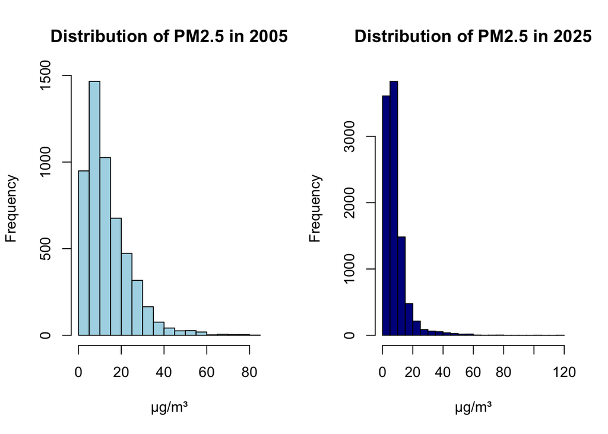

```r
par(mfrow = c(1, 2))
hist(pm_2005$Daily.Mean.PM2.5.Concentration, main = "Distribution of PM2.5 in 2005", xlab = "µg/m³", ylab = "Frequency", col = "lightblue", breaks=20)
hist(pm_2025$Daily.Mean.PM2.5.Concentration, main = "Distribution of PM2.5 in 2025", xlab = "µg/m³", ylab = "Frequency", col = "darkblue", breaks=20)
```

Compare sites in 2005 and 2025

```r
sites_2005 = unique(pm_2005$Site.ID)
length(sites_2005)
```

```
[1] 34
```

```r
sites_2025 = unique(pm_2025$Site.ID)
length(sites_2025)
```

```
[1] 27
```

```r
length(setdiff(sites_2005,sites_2025))
```

```
[1] 17
```

## 2. Join Years

Create Year Column

```r
pm <- rbind(pm_2005,pm_2025)
pm$Year <- as.factor(substr(pm$Date,7,10))
summary(pm$Year)
```

```
2005 2025
5280 9934
```

Rename Columns

```r
pm <- pm %>%
  rename(
    Lat = Site.Latitude,
    Lon = Site.Longitude,
    PM2.5 = Daily.Mean.PM2.5.Concentration
  )
```

## 3. Plot Sites by Year

```r
#contains distinct combinations of SiteID and Year
sites <- pm %>%
  distinct(Site.ID, Year, Lon, Lat)
pal <- colorFactor(palette = c("magenta", "cyan"),
  domain = sites$Year)
sitemap <- leaflet(sites) %>%
  addTiles() %>%
  addCircleMarkers(
    lat = ~Lat, lng = ~Lon, stroke = FALSE,
    color = ~pal(Year), opacity = 1, fillOpacity = 0.5, radius = 8) %>%
  addLegend('bottomleft', pal=pal, values=~Year,
          title='Year') %>%
    addControl(
    html = "<h3>Monitoring Sites by Year</h3>",
    position = "topright"
  )
sitemap
```

[interactive chart not shown]

There is a similar distribution across the two years. Quite a few sites are shared across the two years (lavender). There are more sites that were in 2005 only (magenta) than in 2025 only (cyan).

## 4. Check Data

```r
print(summary(pm))
```

```
     Date              Source             Site.ID               POC
 Length:15214       Length:15214       Min.   :260050003   Min.   :1.000
 Class :character   Class :character   1st Qu.:260810020   1st Qu.:1.000
 Mode  :character   Mode  :character   Median :261390005   Median :1.000
                                       Mean   :261167071   Mean   :1.267
                                       3rd Qu.:261630015   3rd Qu.:1.000
                                       Max.   :261639901   Max.   :5.000

     PM2.5          Units           Daily.AQI.Value  Local.Site.Name
 Min.   :  0.0   Length:15214       Min.   :  0.00   Length:15214
 1st Qu.:  4.5   Class :character   1st Qu.: 25.00   Class :character
 Median :  7.4   Mode  :character   Median : 41.00   Mode  :character
 Mean   : 10.2                      Mean   : 44.07
 3rd Qu.: 12.5                      3rd Qu.: 57.00
 Max.   :116.0                      Max.   :193.00

 Daily.Obs.Count Percent.Complete AQS.Parameter.Code AQS.Parameter.Description
 Min.   :1       Min.   :100      Min.   :88101      Length:15214
 1st Qu.:1       1st Qu.:100      1st Qu.:88101      Class :character
 Median :1       Median :100      Median :88101      Mode  :character
 Mean   :1       Mean   :100      Mean   :88126
 3rd Qu.:1       3rd Qu.:100      3rd Qu.:88101
 Max.   :1       Max.   :100      Max.   :88502

  Method.Code    Method.Description   CBSA.Code      CBSA.Name
 Min.   :118.0   Length:15214       Min.   :10300   Length:15214
 1st Qu.:118.0   Class :character   1st Qu.:19820   Class :character
 Median :170.0   Mode  :character   Median :19820   Mode  :character
 Mean   :391.6                      Mean   :21820
 3rd Qu.:636.0                      3rd Qu.:24340
 Max.   :810.0                      Max.   :42300
 NA's   :2543                       NA's   :854
 State.FIPS.Code    State           County.FIPS.Code    County
 Min.   :26      Length:15214       Min.   :  5.0    Length:15214
 1st Qu.:26      Class :character   1st Qu.: 81.0    Class :character
 Median :26      Mode  :character   Median :139.0    Mode  :character
 Mean   :26                         Mean   :116.7
 3rd Qu.:26                         3rd Qu.:163.0
 Max.   :26                         Max.   :163.0

      Lat             Lon           Year
 Min.   :41.76   Min.   :-89.15   2005:5280
 1st Qu.:42.30   1st Qu.:-85.67   2025:9934
 Median :42.46   Median :-83.60
 Mean   :43.02   Mean   :-84.27
 3rd Qu.:42.98   3rd Qu.:-83.15
 Max.   :47.92   Max.   :-82.46
```

```r
highpm <- pm %>%
  filter(PM2.5 > 70) %>%
  arrange(Year,Date) %>%
  select(Year, Date, PM2.5, Daily.AQI.Value, Local.Site.Name, County)
print(highpm)
```

```
   Year       Date PM2.5 Daily.AQI.Value
1  2005 02/03/2005  73.1             163
2  2005 02/03/2005  75.8             165
3  2005 02/03/2005  71.5             162
4  2005 02/04/2005  75.3             165
5  2005 02/04/2005  73.8             164
6  2005 02/04/2005  75.0             165
7  2005 02/05/2005  81.6             169
8  2005 02/05/2005  79.0             167
9  2005 06/27/2005  79.2             168
10 2025 06/03/2025 100.6             183
11 2025 07/13/2025  72.6             163
12 2025 07/30/2025 116.0             193
13 2025 07/30/2025  78.3             167
14 2025 07/31/2025  72.4             163
```

[output cut: 19 more lines]

On June 2, 2025 there was an air quality advisory due to Canadian wildfires:

https://www.freep.com/story/news/2025/06/02/air-quality-index-advisory-michigan-canada-wildfires-smoke-plumes/83987434007/?gnt-cfr=1&gca-cat=p&gca-uir=true&gca-epti=z112724p000250c000250v112724d--44--b--44--&gca-ft=175&gca-ds=sophi

In late July there was a similar advisory:

https://www.lansingstatejournal.com/story/news/local/michigan/2025/07/25/michigan-air-quality-canadian-wildfire-smoke-pollution-forecast/85370636007/

Therefore, all the values are plausible. Additionally, the AQIs (air quality indices) are very high for these dates, so it is unlikely that the high PM2.5 values are due to measurement errors.

#### Investigate Methods

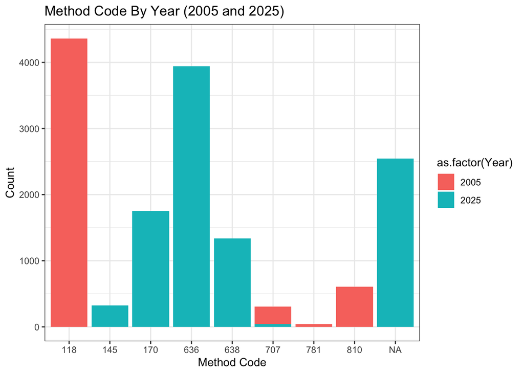

```r
methods <- read.csv("methods_speciation.csv")
ggplot(data = pm) +
  geom_bar(mapping = aes(x=as.character(Method.Code), fill = as.factor(Year))) +
  labs(title='Method Code By Year (2005 and 2025)',x = "Method Code", y="Count") +
  theme_bw()
```

```r
print(pm %>% group_by(Year) %>% summarize(prop_na = mean(is.na(Method.Code))))
```

```
# A tibble: 2 × 2
  Year  prop_na
  <fct>   <dbl>
1 2005    0
2 2025    0.256
```

Almost all collections in 2005 were code 118 while collections in 2025 had more diverse methods with 636 being used the most. Method code 707 was the only one that was utilized in both years. All missing code entries are from 2025 (about 26% percent of entries). One possible explanation for this is that recent measurements (2025) utilize new methods without a method code yet.

```r
print(pm %>% count(Method.Code,AQS.Parameter.Code))
```

```
  Method.Code AQS.Parameter.Code    n
1         118              88101 4361
2         145              88101  324
3         170              88101 1749
4         636              88101 3941
5         638              88101 1336
6         707              88502  309
7         781              88502   44
8         810              88502  607
9          NA              88101 2543
```

Each Method Code has a unique corresponding parameter code, so we can investigate the most common methods.

```r
print(methods[(methods$Method.Code==118 | methods$Method.Code==636) & methods$Parameter.Code == 88101,])
```

```
                   Parameter Parameter.Code Method.Code Recording.Mode
888 PM2.5 - Local Conditions          88101         118   Intermittent
923 PM2.5 - Local Conditions          88101         636     Continuous
                                       Collection.Description
888                  R & P Model 2025 PM2.5 Sequential w/WINS
923 Teledyne T640 at 5.0 LPM w/Network Data Alignment enabled
      Analysis.Description Method.Type Reference.Method.ID
888            GRAVIMETRIC         FRM       RFPS-0498-118
923 Broadband spectroscopy         FEM       EQPM-0516-236
                                         Equivalent.Method Federal.MDL
888                         R & P CO PLUS MODEL 2025PM SEQ         2.0
923 T-API T640 at 5.0 LPM w/Network Data Alignment enabled         0.1
    Min.Value Max.Value Digits Round.Truncate.Indicator
888         0      5000      1                        T
923         0     10000      1                        T
                          Units
888 Micrograms/cubic meter (LC)
923 Micrograms/cubic meter (LC)
```

The two most common methods (most common method for each year) both use the same parameter (PM2.5 - Local Conditions) and have the same units, but vary in collection and analysis method.

## 5. Explore Question

#### 1. Has PM2.5 Concentration Changed in the State of Michigan Over Time?

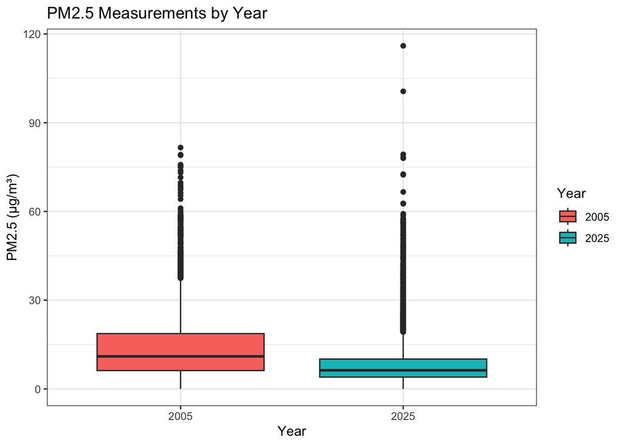

```r
ggplot(data=pm, aes(x=Year, y=PM2.5, fill=Year)) +
  geom_boxplot() +
  labs(title = "PM2.5 Measurements by Year", y="PM2.5 (µg/m³)") +
  theme_bw()
```

```r
print(t.test(PM2.5 ~ Year, data = pm))
```

```
    Welch Two Sample t-test

data:  PM2.5 by Year
t = 33.834, df = 8190, p-value < 2.2e-16
alternative hypothesis: true difference in means between group 2005 and group 2025 is not equal to 0
95 percent confidence interval:
 5.147899 5.781098
sample estimates:
mean in group 2005 mean in group 2025
         13.769924           8.305426
```

```r
print(pm %>%
  group_by(Year) %>%
    summarize(
    mean_pm2.5 = mean(PM2.5),
    sd_pm2.5 = sd(PM2.5),
    min_pm2.5 = min(PM2.5),
    max_pm2.5 = max(PM2.5)
  ))
```

```
# A tibble: 2 × 5
  Year  mean_pm2.5 sd_pm2.5 min_pm2.5 max_pm2.5
  <fct>      <dbl>    <dbl>     <dbl>     <dbl>
1 2005       13.8     10.4          0      81.6
2 2025        8.31     7.42         0     116
```

On average, PM2.5 levels were higher in 2005 (mean = 13.77 µg/m³) than 2025 (mean = 8.31 µg/m³) in Michigan. This reflects an approximately 40% decrease in mean PM2.5 levels; this difference is statistically significant (p<0.05). However, 2025 had higher recorded values (max = 116 µg/m³) than 2005 (max = 81.6 µg/m³).

#### 2. Has PM2.5 Concentration Changed in the State of Michigan by County Over Time?

```r
county_summary <- pm %>%
  group_by(County) %>%
  summarise(
    n_2005 = sum(Year == '2005'),
    n_2025 = sum(Year == '2025'),
    mean_2005 = mean(PM2.5[Year=='2005']),
    mean_2025 = mean(PM2.5[Year=='2025']),
    sd_2005 = sd(PM2.5[Year=='2005']),
    sd_2025 = sd(PM2.5[Year=='2025']),
    pct_change = if(mean_2005 != 0 & !is.na(mean_2005) & !is.na(mean_2025)){
      100 * (mean_2025 - mean_2005) / mean_2005
    } else {
      NA_real_
    },
    p_value = if (n_2005 >= 2 & n_2025 >=2){
      t.test(PM2.5[Year=='2005'],PM2.5[Year=='2025'])$p.value
    } else {
      NA_real_
    },
    significant = p_value < 0.05,
    .groups = 'drop'
  ) %>% arrange(desc(pct_change))
county_summary
```

```
# A tibble: 25 × 10
   County n_2005 n_2025 mean_2005 mean_2025 sd_2005 sd_2025 pct_change   p_value
   <chr>   <int>  <int>     <dbl>     <dbl>   <dbl>   <dbl>      <dbl>     <dbl>
 1 Schoo…    117    353      5.56      6.57    5.48    8.48       18.1 1.38e-  1
 2 Alleg…    421    359     12.7       8.95    9.41    5.98      -29.6 3.02e- 11
 3 Bay       117    370     12.4       8.54    9.34    6.30      -31.3 4.27e-  5
 4 Kent      475    796     14.3       9.81   10.5     7.07      -31.3 7.31e- 16
 5 Kalam…    228    399     14.7       9.07    8.89    7.24      -38.4 3.67e- 15
 6 Ingham    120    363     13.5       7.87    9.19    7.05      -41.9 4.61e-  9
 7 Ottawa    117    365     13.9       7.74    9.49    7.16      -44.5 9.34e- 10
 8 Macomb    120    365     14.4       7.88   11.4     7.26      -45.1 2.70e-  8
 9 Wayne    1643   3549     16.5       9.01   11.2     7.00      -45.5 9.07e-122
10 Missa…    167    351      9.86      5.32    7.71    6.23      -46.1 1.64e- 10
# ℹ 15 more rows
# ℹ 1 more variable: significant <lgl>
```

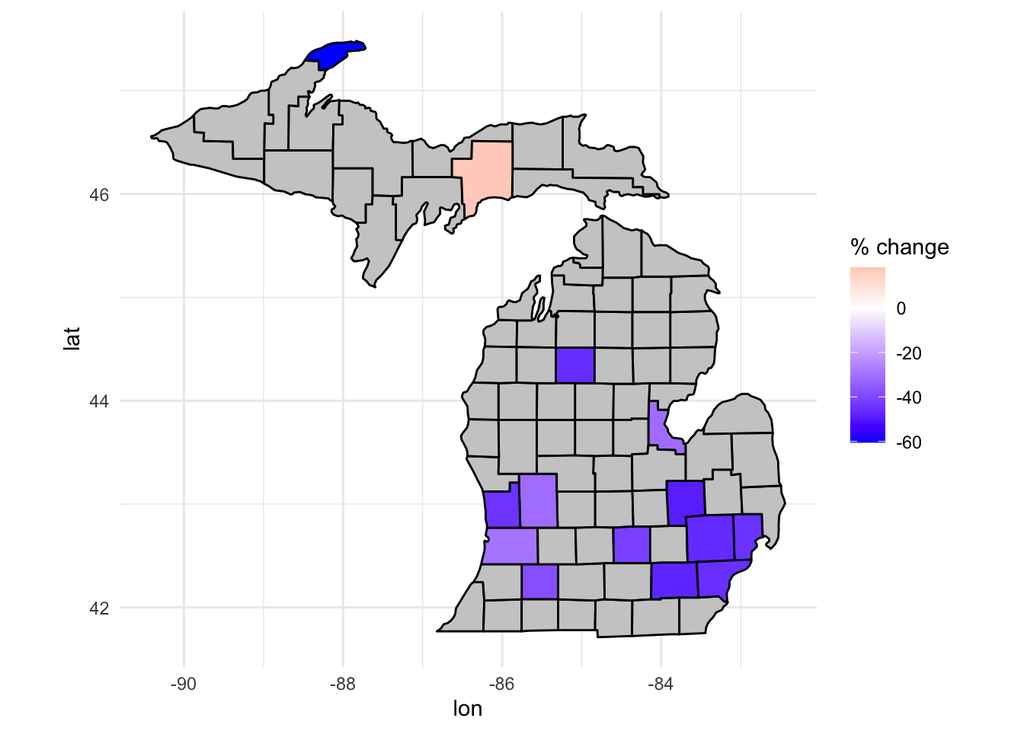

```r
# Retrieve Michigan county data
mi_counties <- map_data("county", "michigan") %>%
  select(lon = long, lat, group, County = subregion) %>%
  mutate(County = str_to_sentence(County))
#Join with County Summaries
mi_counties <- left_join(mi_counties, county_summary, by="County")
# Plot using geom_polygon
ggplot(mi_counties, aes(x = lon, y = lat, group = group)) +
  geom_polygon(aes(fill = pct_change), color = "black") +
  scale_fill_gradient2(
    low = "blue",
    mid = "white",
    high = "tomato",
    midpoint = 0,
    na.value = "grey80",   # ← NA color here
    name = "% change"
  ) +
  coord_fixed(1.3) +
  theme_minimal()
```

#### 3. Has PM2.5 Concentration Changed in the Wayne County by Site Over Time?

```r
wayne_summary <- pm %>%
  filter(County=="Wayne") %>%
  group_by(Site.ID,Local.Site.Name) %>%
  summarise(
    n_2005 = sum(Year == '2005'),
    n_2025 = sum(Year == '2025'),
    mean_2005 = mean(PM2.5[Year=='2005']),
    mean_2025 = mean(PM2.5[Year=='2025']),
    sd_2005 = sd(PM2.5[Year=='2005']),
    sd_2025 = sd(PM2.5[Year=='2025']),
    pct_change = if(mean_2005 != 0 & !is.na(mean_2005) & !is.na(mean_2025)){
      100 * (mean_2025 - mean_2005) / mean_2005
    } else {
      NA_real_
    },
    p_value = if (n_2005 >= 2 & n_2025 >=2){
      t.test(PM2.5[Year=='2005'],PM2.5[Year=='2025'])$p.value
    } else {
      NA_real_
    },
    significant = p_value < 0.05,
    .groups = 'drop'
  ) %>% arrange(desc(pct_change))
wayne_summary
```

```
# A tibble: 15 × 11
     Site.ID Local.Site.Name   n_2005 n_2025 mean_2005 mean_2025 sd_2005 sd_2025
       <int> <chr>              <int>  <int>     <dbl>     <dbl>   <dbl>   <dbl>
 1 261630015 "DETROIT-SOUTHWE…    114    461      17.2      9.23   11.2     6.89
 2 261630033 "PROPERTY OWNED …    170    465      18.9      9.35   11.6     7.26
 3 261630001 "Allen Park"         523    446      16.2      7.96   10.8     6.62
 4 261630019 "East 7 Mile"        117    364      16.4      7.57   12.0     6.66
 5 261630016 "DET-LINWOOD"        338      0      16.0    NaN      11.5    NA
 6 261630025 "SCHOOLCRAFT COL…    114      0      14.9    NaN      10.7    NA
 7 261630036 "92 FEET FROM WH…    113      0      16.4    NaN      10.7    NA
 8 261630038 "Newberry School"     75      0      16.4    NaN      12.0    NA
 9 261630039 "FIA/Lafayette"       35      0      15.0    NaN       9.17   NA
10 261630093 "Eliza Howell-NR"      0    357     NaN       11.6    NA       6.69
11 261630097 "NMH48217 NEW MT…      0    365     NaN        8.33   NA       6.90
12 261630098 "DP4th - Detroit…      0    363     NaN        9.67   NA       7.19
13 261630099 "TRINITY ST MARK…      0    365     NaN        9.14   NA       7.36
14 261630100 "Military Park (…      0    363     NaN        8.43   NA       6.67
15 261639901 ""                    44      0      19.6    NaN      13.5    NA
# ℹ 3 more variables: pct_change <dbl>, p_value <dbl>, significant <lgl>
```

```r
complete_wayne_sites <- wayne_summary %>%
  filter(n_2005>0 & n_2025>0) %>%
  pull(Local.Site.Name)
complete_wayne_sites
```

```
[1] "DETROIT-SOUTHWEST (DET-SW)"
[2] "PROPERTY OWNED BY DEARBORN PUBLIC SCHOOLS"
[3] "Allen Park"
[4] "East 7 Mile"
```

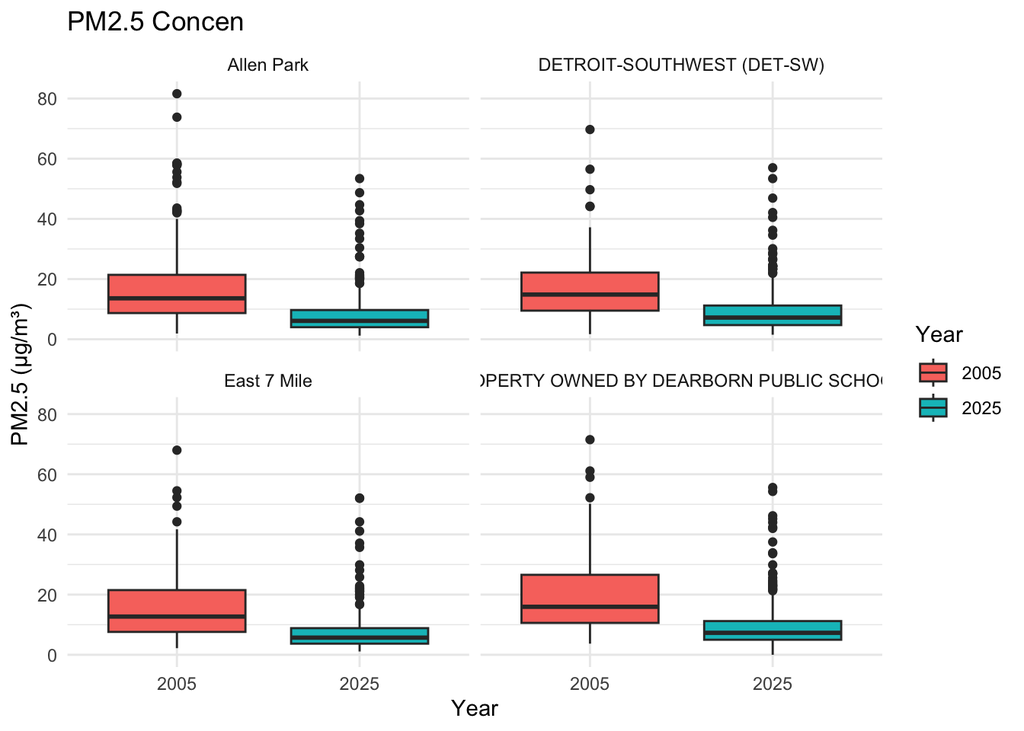

```r
wayne_plot<- pm %>%
  filter(Local.Site.Name %in%complete_wayne_sites) %>%
  ggplot(aes(x=Year, y=PM2.5, fill=Year)) +
  geom_boxplot() +
  facet_wrap(~ Local.Site.Name) +
  theme_minimal() +
  labs(x = "Year", y = "PM2.5 (µg/m³)",title="PM2.5 Concen")
wayne_plot
```

Only 4 sites in Wayne County had collected PM2.5 levels in both 2005 and 2025: Allen Park, Southwest Detroit, East 7 Mile, and Dearborn Public Schools. All 4 sites showed a statistically significant decrease (p<0.05) in mean PM2.5 levels from 2005 to 2025. The decrease ranged from about 46% (Southwest Detroit) to 54% (East 7 Mile). This is a greater percent change than the state average across the two years (40%).

#### Conclusions

On average, PM2.5 levels **decreased** from 2005 to 2025 in Michigan on a state, county and site (Wayne County) level. However, there were some exceptions such as the highest maximum PM2.5 level occuring in 2025 and Schoolcraft County having higher PM2.5 levels in 2025 than 2005. The analysis on county and site levels was limited by unavailable data in one of the two years. Only counties/sites with data in both 2005 and 2025 were used. In future analysis, nearby sites with data in one of the years could be matched to have further data points.